# Hitter Development Report

← Team overview · League overview

# Charles McAdoo

**2026 season · Profile: Balanced · xwOBA 0.289 (11th percentile)**

**Small sample:** 167 competitive swings in 2026. Bat speed stabilises quickly, but contact and outcome metrics should be read as early signals, not conclusions.

Charles McAdoo squares up the ball at a poor rate (8th percentile) with bat speed in the 70th percentile. Main lever: **turn existing bat speed into quality contact.**

## Swing profile vs MLB

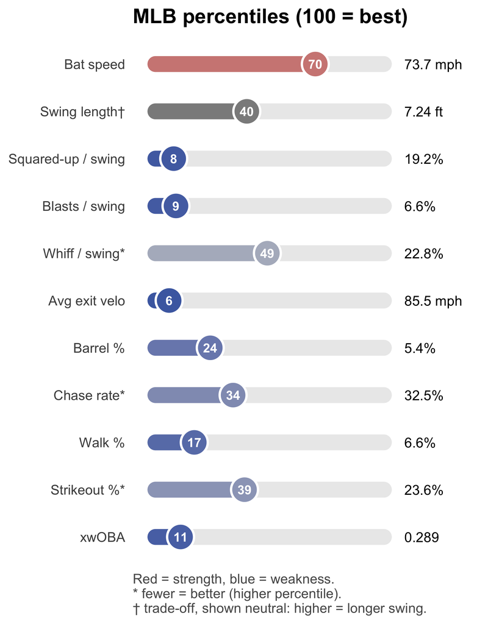

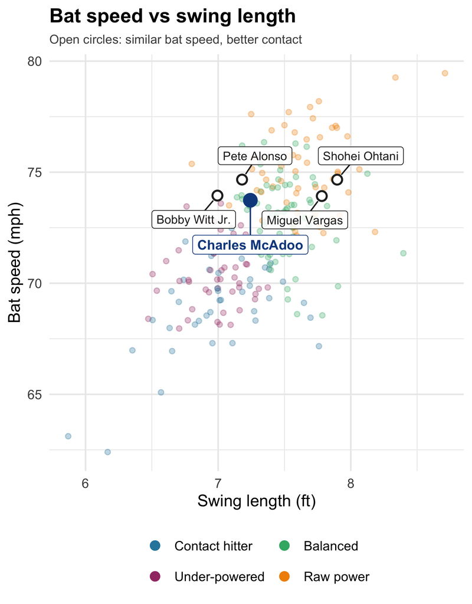

## Year-over-year

| Season | Bat speed (mph) | Swing length (ft) | Squared-up / swing | Whiff / swing | xwOBA | wOBA (actual) |
| --- | --- | --- | --- | --- | --- | --- |
| 2026 | 73.7 | 7.24 | 19.2% | 22.8% | 0.289 | 0.303 |

## What the model says

Across 232 qualified MLB hitters in 2026, at equal swing length, contact and whiff rate, **+1 mph of bat speed is associated with +10 points of xwOBA**, and +1 point of squared-up rate with +4 points. The swing metrics explain 42% of the differences in production between hitters; adding swing decisions (chase and in-zone swing rates) raises it to 47%. The rest comes from timing, launch direction and factors public data does not capture.

These are cross-sectional associations, not guarantees: they set the hypothesis to test with the player, not the expected outcome.

## Development plan

**Diagnosis.** Charles McAdoo already generates above-average bat speed (73.7 mph, 70th percentile), but his contact quality (8th percentile in squared-up rate) and whiff rate (49th percentile) limit how much of that speed turns into damage.

**Priority.** Convert speed into quality contact.

1. **Screen** – Swing length, attack angle and path vs pitch location; timing.
2. **Intervene** – Constraint-based drills for a more efficient path; timing work.
3. **Monitor** – Squared-up and whiff rates each week, with bat speed protected.

Reference points – similar bat speed, better contact

| Comparable hitter | Bat speed (mph) | Squared-up / swing | xwOBA |
| --- | --- | --- | --- |
| Pete Alonso | 74.7 | 25.1% | 0.402 |
| Shohei Ohtani | 74.7 | 25.3% | 0.397 |
| Bobby Witt Jr. | 73.9 | 27.4% | 0.378 |
| Miguel Vargas | 73.9 | 26.3% | 0.378 |

Data: Baseball Savant, public Statcast data (bat tracking, expected stats, exit velocity). Bat speed = average of the top 90% of competitive swings. Percentiles (1–100), model and profiles are based on the 232 qualified MLB hitters in 2026 (570+ competitive swings). Profiles: k-means on bat speed, swing length, squared-up and whiff rates. Internal biomechanics data would replace the screening hypotheses with measured values. Report: Hugo Leligny.

Hugo Leligny · Sport Scientist & Performance Analyst  
Measure → Analyze → Decide → Train → Monitor → Adapt ↻  
hugoleligny14@gmail.com · [GitHub](https://github.com/hugollel/blue-jays-hitting)